# BIOST 561: unit testing

Lecture 5

# Announcements

- Your HW2’s look great – I’ll be grading them this weekend
- You probably got an email from `UW Course Evaluations via IASystem Notification` about this course’s midterm course feedback. It would mean a lot to me if you filed it out

# Why unit testing?

- A unit test is **additional** code you write to verify some quality about your function
- Then, there’s a way to automatically run all your unit tests
- This concept extends well beyond R, but we’ll be learning how it works in R for this course

# Why do we need a formal way to run our tests?

[figure not shown]

- What are 2 reasons we would want a more formal way to test code?
- You want some confidence that when you use your function in “real” situations, your code is doing what you think it’s doing
- Your code evolves over time, so you want to make sure you don’t introduce extra bugs
- Your unit tests are, in a way, documentation
  - Your are “documenting” what is the expected behavior of your functions
- You want some confidence that when you use your function in “real” situations, your code is doing what you think it’s doing
- Your code evolves over time, so you want to make sure you don’t introduce extra bugs
- Your unit tests are, in a way, documentation
  - Your are “documenting” what is the expected behavior of your functions
- (My personal opinion): **If you do not know how to test your code, then you don’t really understand your own code**
  - Corollary: If you don’t know how to design a setting where you know what should happen, then you don’t really understand your own code

# Your Q4 in HW2

Suppose your teammate gave you a function to find the **maximal clique** in an adjacency matrix (i.e., the set of nodes that forms the largest clique). You are not told the typical size and characteristics of these adjacency matrices beforehand. Your job is to make sure this function is correct since you and your teammate are about to give this function to your manager, who will then give it to another division in your company to use. Your performance review will depend highly on whether or not other people in your company can reliably use your function.

In a short paragraph, write down ways to ensure your teammate’s function is “correct.” Please list at least four different ways you can test this function. You can interpret this notion of “correct” very liberally – this question is purposely framed to be open-ended.

# On the screen, as a group

- What did you write for this question?
- What “foreseeable concerns/nightmares” are you trying to avoid by writing unit tests?

# Types of unit tests

- In the next few slides, I copy-pasted (more-or-less verbatim) what you guys wrote
  - All I did was organize them into categories

**Checking that the function outputs something that is the correct type**

- “One method in which I would use to ensure my teammates function works at a basic level is to test whether it stops the function from running for inputs that are invalid (such as non-matrices).”
- (This is 2025 student): “Try passing something that is not a matrix, like a data frame, through the function and see if it returns an answer. If it does, it is not correctly checking the data structure that needs to be used in the function.”

**Simple checks to make sure result is within the correct range**

- (This is 2025 student): “We could also add a check to ensure the inputs and output are the data types we would expect.”
- (This is 2025 student): “First I would make sure that the function returned a valid set of nodes for normal-ish matrixes that I would expect it would be given.”

**Making sure the function runs on many different inputs (or same input, if there’s randomness in the method)**

- (This is 2025 student): “Repeat test on the same adjacency matrix, to check if the output is the same.”
- (This is 2025 student): “We could generate graphs with a known maximal clique, using say `generate_random_graph` with a low density and different sizes of cliques.”
- (This is 2025 student): “I’d also try random graphs where there aren’t any big cliques, just to make sure it doesn’t find something that isn’t there.”

**Making sure the function gets the correct answer for carefully crafted problem**

- “A better way to ensure the function works correctly is to create a toy example of a given adjacency matrix (similar to how we created one with a pre-specified clique s.t. we know the largest clique size and then shuffled it)”
- “We can test the function by running small hand-crafted examples such as a 3-node clique to confirm the function returns exactly those three nodes by manual checking.”
- “Create a an adjacency matrix where the maximal clique is known and verify the function returns the correct nodes”
- (This is 2025 student): “Again, use a random adjacency matrices with very low edge density, manually insert a planted clique, as big as enough to ensure it is the largest. Then, run the function to check if it can detect.”
- (This is 2025 student): “I will create graphs that have cliques of different sizes and make sure it picks the biggest one.”

**Making sure the function gets the correct answer with many randomly generated problems**

- “I would manually create several matrices to test their function with. For the functions I create, I would know the actual maximal clique within my matrices to then verify my teammates’ function with them.”
- (This is 2025 student): “Randomly add or remove a few edges from an adjacency matrix, to check if the function can detect the same main clique as the original one.”
- (This is 2025 student): “Create random adjacency matrices with very high edge density, to check if the function can find the correct large clique.”

**Stress testing to make sure the function handles corner cases gracefully**

- “First, I would use very small graphs where I can manually check the answer, such as an empty graph, a graph with one node, a triangle, or a square with no diagonals.”
- “We can test the function by some edge cases (empty graph with no edges or a complete graph with every node connected to every other).”
- “Test the empty graph, all zeros, and complete graph,all ones, with isolated nodes.”
- “Second, I would test special cases, such as a complete graph where every node is connected to every other node, because the maximal clique should include all nodes.”
- “Third, I would test graphs with no edges, where the largest clique should have size 1.”
- (This is 2025 student): “Come up with specific examples of graphs with NO cliques and make sure the function returns an empty set.”

**Comparing against another known implementation**

- “use *generate_random_graph* with known *clique_fraction* and verify if the function recovers exactly those planted clique nodes”
- (This is 2024 student): “Use the function in conjunction with other clique-finding algorithms or software, where possible, to cross-verify results. Discrepancies can help identify specific situations where the function may fail.”

**Comparing against another one of your implementations (possibly much more computationally intensive, but more transparent and definitely correct)**

- (This is 2024 student): “The third way is to write another algorithm by myself, testing it by inputting several randomly generated adjacency matrix to find out the maximal clique, and compare my results with the results generated from my teammate’s function.”

**Math: Exploiting some mathematical property of your problem**

- “By permuting rows and columns and re-running the function, if the output adjacency matrix is symmetry, our function is correct”
- “Since we know which node indices correspond to the planted clique from *generate_random_graph()*, we can compare the output of our functions with rev_order(), the known answer in generate_random_graph() to check the correctness.”
- “permute rows and columns like the *adj_mat2* and verify the function returns the same clique inspite of node ordering.”
- “Fourth, I would create graphs with a known planted clique, then randomly permute the rows and columns of the adjacency matrix to make sure the function still finds the same clique after relabeling the nodes.”
- (This is 2025 student): “Pass a test matrix through that has two large cliques, but one that is just slightly larger than the other. If the function incorrectly identifies the other clique as the maximal clique, it is incorrect.”
- (This is 2025 student): “I’ll also double-check that whatever it returns is actually a real clique, meaning all the nodes are connected to each other.”

**Testing the timing and memory of your function**

- (This is 2025 student): “Pass larger and larger matrices through the function to make sure it can handle larger calculations without overflowing.”
- (This is 2025 student): “If this ‘correctness’ includes efficiency, meaning it does not blow up in time for expected size of data, and also looking at the structure of code, method used, etc.”

**Testing to make sure it errors when expected**

- (This is 2025 student): “Then I would move to more error handling, type checking, etc, once I knew the algorithm worked well. This would involve giving the function strings, scalers, other function, and other weird stuff.”
- (This is 2025 student): “Pass in incorrect arguments to the function (e.g wrong type of data) and make sure the function either warns the user or throws an error”

**Testing the coding environment**

- (This is 2025 student): “Check if this function runs correctly when called in other projects.”
- (This is 2024 student): “I will also check if this function can run well in different environments, which means that it doesn’t rely on something only in my colleague’s computer.”

**Checking the documentation/literal coding**

- “A straightforward way to check the function, although quite error prone if not actually testing the code itself, is to visually read through the code and/or work through the operations by hand and see if everything makes sense/would be suspected to run correctly.”
- (This is 2024 student): “With the help of `help()` in R to make sure the description and the code is with the same logic.”
- (This is 2024 student): “You can make sure they follow the company’s style guide and coding grammar.”
- (This is 2024 student): “I might consider the function’s readability as a relevant consideration, because if the code is a gargled mess people in the company will have difficulty using it.”

**Checking the intermediary functions!**

- (This is 2025 student): “If this ‘correct’ include perspective of checking the algorithm, we can test infinite loops, correct intermediate steps. If it include tree structures I believe there are correctness test for those too.”
- (This is 2024 student): “A more tedious method is to run the intermediate functions one at a time to verify if each step of our new function adheres to the intended logic and generate the desired results independently.”

**Testing the behavior when there is deliberately no unique answer**

- (This is 2024 student): “Check the output when graphs contain multiple equally sized maximal cliques.”

**Using AI to help out**

- “AI could also assist in verifying the function’s cleanliness, seeing any errors, and running through examples by pasting the function and a prompt (i.e. I have this function - are there any errors and if so, please identify them … etc … could you also create a few test matricies to verify the result, etc.) into some tool like Gemini or ChatGPT.”

# So… what does this show?

- **You** actually know quite a lot of ways to make sure your code is correct!
- As you can see, there’s (broadly speaking) two main categories of tests
  - **Completion**: Does my code run and terminate when it receives different inputs?
  - **Correctness**: Is my code giving the correct output?
  - Many other things you discussed aren’t “tests” that can be easily automated. (More on this later!)
- There’s only one “type” of unit tests that I use that I did not see people mention in their homeworks (unless I missed it when looking at your HW2s)
  - More on this later!

# What’s the goal?

- A unit test is a short script you write that:
  - “has a function do something”
  - “checks the output”
- This is to ensure that the function “works”

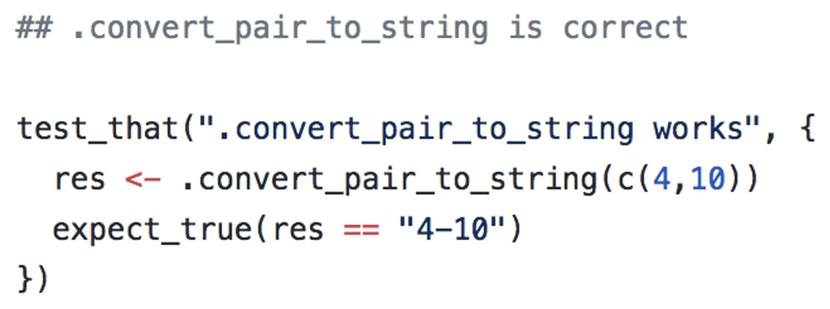

- You ideally should be writing unit tests for each function you write. The more you “refactor” your functions (into more manageable smaller functions), the easier you’ll know what tests to write.
- R Studio and R packages are convenient for easily running all your unit tests, so you can easily assess how “stable” your codebase is.
- This can be painful!! Whenever you update your method, you might need to update your unit tests. However, this should be a “rolling experience” – as you find new bugs in your code, you should be writing more unit tests.

# A personal note

- In my experience, most PhD students I talk to cannot be bothered to write unit tests since it’s a pain to write/maintain all this “additional code.”
- At the same time, in my experience, it’s not a matter of “whether or not my codebase crashes,” but rather a question of **“what time in the future will my codebase become so complicated that everything starts to fail at the same time?”**

# A personal note

- In my experience, most PhD students I talk to cannot be bothered to write unit tests since it’s a pain to write/maintain all this “additional code.”
- At the same time, in my experience, it’s not a matter of “whether or not my codebase crashes,” but rather a question of **“what time in the future will my codebase become so complicated that everything starts to fail at the same time?”**
- After you’ve had your **first traumatic experience of your codebase failing**, come back to these slides and learn more about how to write unit-tests so you don’t need to relive the trauma in the future.

# Setting up unit tests in R

- There’s a lot of “rules” on how to set up unit tests in an R package
- Let’s take a look at the demo package for this course: https://github.com/linnykos/561_s2026_example (Screenshot from the 2024 version)
- You’ll notice a `tests` folder:

[figure not shown]

- This is where all your tests will live – it’s just another specifically named R folder
  - It **must** be a folder called `tests`
- If we click into folder https://github.com/linnykos/561_s2026_example/tree/main/tests, we will see another folder called `testthat` and a `testthat.R`
  - There **must** be a folder called `testthat` and a `.R` file called `testthat.R`
  - (You don’t need a `.DS_Store` file)

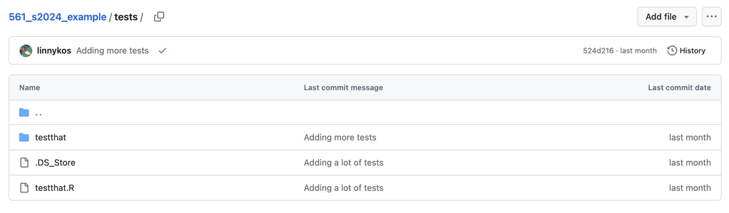

- If we look at the `testthat.R` folder, you’ll see that it’ll look like this
  - Every `testthat.R` file you ever write will only have these **specifically these three lines**.

```r
library(testthat)
library(UWBiost561)

test_check("UWBiost561")
```

See this in:

[figure not shown]

- Now let’s click into the `testthat` folder: https://github.com/linnykos/561_s2026_example/tree/main/tests/testthat

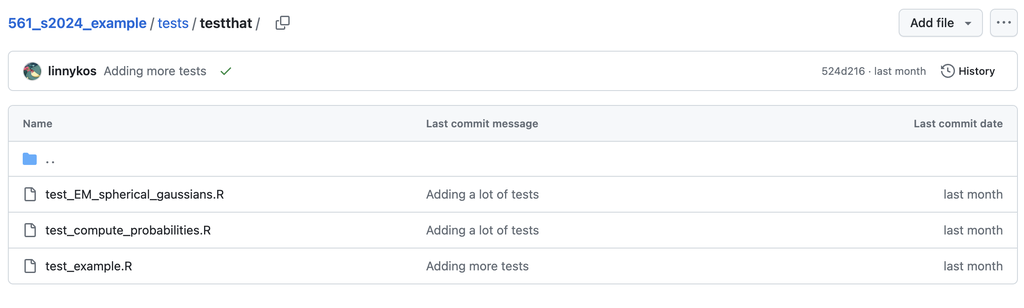

- This is where your unit tests live
  - Usually (but not required), I make one `.R` file in the `testthat` folder for every `.R` file in the `R` folder (where your functions live)
  - This helps keeps things organized – You can easily find the function definitions (in the `R` folder) and its corresponding tests (in the `testthat` folder)

# An example of unit test

Let’s look into the unit tests in `test_compute_probabilities.R`: https://github.com/linnykos/561_s2026_example/blob/main/tests/testthat/test_compute_probabilities.R

[figure not shown]

- First: The start of a `.R` file in the `testthat` folder is the **context**
  - What is the goal of these tests in the `.R` file?
  - Usually, I just write: “Testing [the functions in the corresponding `.R` file in the `R` folder]”

```
context("Testing compute_probabilities")

# Unit test for compute_log_probabilities
test_that("compute_probabilities outputs correctly", {
  set.seed(10)
  # Mock data and parameters for testing
  data <- matrix(rnorm(20), nrow = 10, ncol = 2) # 10 samples, 2-dimensional
  means <- matrix(c(0, 0, 5, 5), nrow = 2, byrow = TRUE) # 2 components
  variances <- c(1, 2)
  proportions <- c(0.5, 0.5)

  probabilities <- compute_probabilities(data, means, variances, proportions)

  # Test if probabilities sum to 1 for each sample
  expect_true(all(abs(rowSums(probabilities) - 1) < 1e-6))

  # Test if probabilities are within the valid range [0,1]
  expect_true(all(probabilities >= 0 & probabilities <= 1))

  # Test for handling of a single sample (edge case)
  single_sample <- data[1, , drop = FALSE] # Prevent dropping to lower dimension
  probabilities_single <- compute_probabilities(single_sample,
                                                means,
                                                variances,
                                                proportions)
  expect_true(dim(probabilities_single)[1] == 1)
  expect_true(all(abs(rowSums(probabilities_single) - 1) < 1e-6))
})
```

- Next: Each unit test is wrapped inside a `test_that()` function.
  - The first argument is always a string (usually a short sentence describing what this test does)
  - The second “argument” is a code block. It is **always** sandwiched within a `{}` block.

```
context("Testing compute_probabilities")

# Unit test for compute_log_probabilities
test_that("compute_probabilities outputs correctly", {
  set.seed(10)
  # Mock data and parameters for testing
  data <- matrix(rnorm(20), nrow = 10, ncol = 2) # 10 samples, 2-dimensional
  means <- matrix(c(0, 0, 5, 5), nrow = 2, byrow = TRUE) # 2 components
  variances <- c(1, 2)
  proportions <- c(0.5, 0.5)

  probabilities <- compute_probabilities(data, means, variances, proportions)

  # Test if probabilities sum to 1 for each sample
  expect_true(all(abs(rowSums(probabilities) - 1) < 1e-6))

  # Test if probabilities are within the valid range [0,1]
  expect_true(all(probabilities >= 0 & probabilities <= 1))

  # Test for handling of a single sample (edge case)
  single_sample <- data[1, , drop = FALSE] # Prevent dropping to lower dimension
  probabilities_single <- compute_probabilities(single_sample,
                                                means,
                                                variances,
                                                proportions)
  expect_true(dim(probabilities_single)[1] == 1)
  expect_true(all(abs(rowSums(probabilities_single) - 1) < 1e-6))
})
```

- Inside the test, of course, you need to create the “inputs” for your function

```
context("Testing compute_probabilities")

# Unit test for compute_log_probabilities
test_that("compute_probabilities outputs correctly", {
  set.seed(10)
  # Mock data and parameters for testing
  data <- matrix(rnorm(20), nrow = 10, ncol = 2) # 10 samples, 2-dimensional
  means <- matrix(c(0, 0, 5, 5), nrow = 2, byrow = TRUE) # 2 components
  variances <- c(1, 2)
  proportions <- c(0.5, 0.5)

  probabilities <- compute_probabilities(data, means, variances, proportions)

  # Test if probabilities sum to 1 for each sample
  expect_true(all(abs(rowSums(probabilities) - 1) < 1e-6))

  # Test if probabilities are within the valid range [0,1]
  expect_true(all(probabilities >= 0 & probabilities <= 1))

  # Test for handling of a single sample (edge case)
  single_sample <- data[1, , drop = FALSE] # Prevent dropping to lower dimension
  probabilities_single <- compute_probabilities(single_sample,
                                                means,
                                                variances,
                                                proportions)
  expect_true(dim(probabilities_single)[1] == 1)
  expect_true(all(abs(rowSums(probabilities_single) - 1) < 1e-6))
})
```

- Then, of course, for the test for `compute_probabilities`, we need to actually use the `compute_probabilities` function.
  - The output in this example is `probabilities`
  - We will be checking if the output `probabilities` is what we expect

```
context("Testing compute_probabilities")

# Unit test for compute_log_probabilities
test_that("compute_probabilities outputs correctly", {
  set.seed(10)
  # Mock data and parameters for testing
  data <- matrix(rnorm(20), nrow = 10, ncol = 2) # 10 samples, 2-dimensional
  means <- matrix(c(0, 0, 5, 5), nrow = 2, byrow = TRUE) # 2 components
  variances <- c(1, 2)
  proportions <- c(0.5, 0.5)

  probabilities <- compute_probabilities(data, means, variances, proportions)

  # Test if probabilities sum to 1 for each sample
  expect_true(all(abs(rowSums(probabilities) - 1) < 1e-6))

  # Test if probabilities are within the valid range [0,1]
  expect_true(all(probabilities >= 0 & probabilities <= 1))

  # Test for handling of a single sample (edge case)
  single_sample <- data[1, , drop = FALSE] # Prevent dropping to lower dimension
  probabilities_single <- compute_probabilities(single_sample,
                                                means,
                                                variances,
                                                proportions)
  expect_true(dim(probabilities_single)[1] == 1)
  expect_true(all(abs(rowSums(probabilities_single) - 1) < 1e-6))
})
```

- You need to use the function `expect_true()` to let R know that you expect a particular statement to be true.
  - Of course, the statement **inside** `expect_true()` is itself code that will be evaluated
  - If the output a single `TRUE` boolean, then the test will pass (but I have not yet showed you how these tests are run!)

```
context("Testing compute_probabilities")

# Unit test for compute_log_probabilities
test_that("compute_probabilities outputs correctly", {
  set.seed(10)
  # Mock data and parameters for testing
  data <- matrix(rnorm(20), nrow = 10, ncol = 2) # 10 samples, 2-dimensional
  means <- matrix(c(0, 0, 5, 5), nrow = 2, byrow = TRUE) # 2 components
  variances <- c(1, 2)
  proportions <- c(0.5, 0.5)

  probabilities <- compute_probabilities(data, means, variances, proportions)

  # Test if probabilities sum to 1 for each sample
  expect_true(all(abs(rowSums(probabilities) - 1) < 1e-6))

  # Test if probabilities are within the valid range [0,1]
  expect_true(all(probabilities >= 0 & probabilities <= 1))

  # Test for handling of a single sample (edge case)
  single_sample <- data[1, , drop = FALSE] # Prevent dropping to lower dimension
  probabilities_single <- compute_probabilities(single_sample,
                                                means,
                                                variances,
                                                proportions)
  expect_true(dim(probabilities_single)[1] == 1)
  expect_true(all(abs(rowSums(probabilities_single) - 1) < 1e-6))
})
```

# Using `devtools::check()`

- How do you run all your tests though?
- The most straightforward way is to use `devtools::check()` in the R console. (Technically, if you **only** want to run your tests and nothing else, you can use `devtools::test()`.)
- You run this **in your R console** (not in a Markdown file)

[figure not shown]

- The end of the output would look something like this

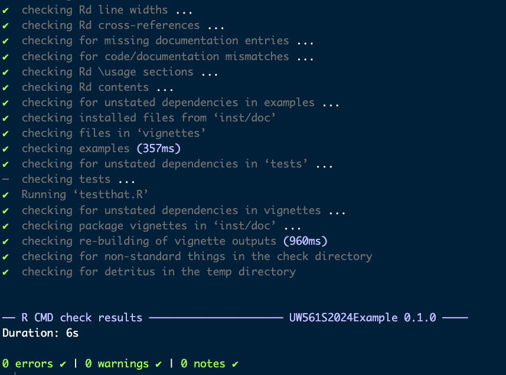

- The **easiest** way though is to simply click the button in the Dropdown menu under `Build`.

[figure not shown]

- Be aware. You **must** be in a R project where the `.Rproj` file is in the top folder of your R package. That is, your files should look something like this

[figure not shown]

- If you are not in an R project, when you run `devtools::check()`, this happens. (Essentially, R doesn’t know what R package you’re trying to test.)

[figure not shown]

- Check in-class demonstration on the `UWBiost561` package
- Going over `devtools::test()` and `devtools::check()` – what the results look like when a test fails
- Going over what else `devtools::check()` looks at

# Three more things: refactoring your code

- Consider an analogy of an assembly line to make to an electric car
  - It’s **very** hard to check the final car if you never did any other checks
    - How can you possibly look through every component under the car, especially if they’re screwed in tightly or hard to access?
  - Instead, it’ll be better to **check each component separately**
- This is the idea of refactoring your code
  - If you have a complicated function, you’ll want to split into smaller functions so it’s more straightforward on how to test those smaller functions

# Second: “contracts” (checking the inputs and outputs)

- It’s often useful to write code **inside your function** (i.e., not in the `testthat` folder, but in the `R` folder)
- This is often done by using either the `stopifnot()` function or the `stop()` function

```
cleanup_na_matrix <- function(mat){
  stopifnot(is.matrix(mat), all(is.numeric(mat)))

  n <- nrow(mat)
  p <- ncol(mat)
  mat <- sapply(1:p, function(j){
    .cleanup_vector(mat[,j])
  })

  return(mat)
}
```

Alternative:

```
cleanup_na_matrix <- function(mat){
  if(!is.matrix(mat) | !all(is.numeric(mat)))
    stop("mat is not a numeric matrix")

  n <- nrow(mat)
  p <- ncol(mat)
  mat <- sapply(1:p, function(j){
    .cleanup_vector(mat[,j])
  })

  return(mat)
}
```

- See https://dlang.org/spec/contracts.html for more information.

# Third: the limitations of unit testing

- It is hard to test that a plotting function is “correct”. (I’ve often found it’s not worth the effort to code tests for this.)
- As your functions (especially statistical estimators) get more complicated, it’s often harder to come up with meaningful tests of “correctness”
  - We’ll do an exercise in just a bit to showcase this
- Even you wrote many tests, it does **not** mean:
  - Your code is readable or is well documented – This was what we discussed in Lecture 4
  - Your code works in different environments
  - Your code is efficiently coded (with respect to how much time it takes to run) – This will be the focus of Lecture 6
  - Your function is easy to use or has reasonable default values
- However, testing **does** accomplish a lot of things nonetheless!

# Words of wisdom

- **Always** test your functions **as** you are developing your code.
  - It is **extremely** painful to test your functions when you’re done with your project
  - Also, you’ll be **very terrified** if you finish your project, and **then** realize some of your functions have a critical failure
- The more you “refactor” your functions (into more manageable smaller functions), the easier you’ll know what tests to write.
  - It’s easier to write many tests for functions that each do specific things, rather than 200+ line monstrosity
- As you fix bugs in your code, you should be writing more unit tests to make sure that bug does not reappear in the future

# In-class exercise: Bootstrap confidence intervals

- If time ie permitting, let’s come up with ideas on how to test a bootstrap confidence interval for linear regression.

```r
bootstrap_lm_coef <- function(X, y, alpha = 0.05, nboot = 1000){
  # something is done here
}
```

- Observe: The bootstrap is a random procedure, so it’s hard to test if the code is “correct” because it’s not easy to construct a simple setting where you know what the “correct” answer is
- However, you **do** know that the intervals should get wider as `alpha` gets smaller
  - Hence, you can compare extreme cases: The intervals for `alpha=0.5` (i.e., 50% confidence interval) should be much smaller than the intervals for `alpha=0.01` (i.e., 99% confidence interlva) for the vast majority of instances
  - That is, you can show your method is “correct” by comparing the relation between different outputs
  - Most complex statistical methods have some type of “monotonic” behavior (although it might be probabilistic in nature)
- If you design your own classifier, **you** can create inputs that you know are “easy” or that are “hard”, and you can see that the classifier has a higher accuracy on the “easy” settings than the “hard” settings
- In the maximal clique question in your homework, you can test that if you add edges to a graph, the maximal clique should never get smaller

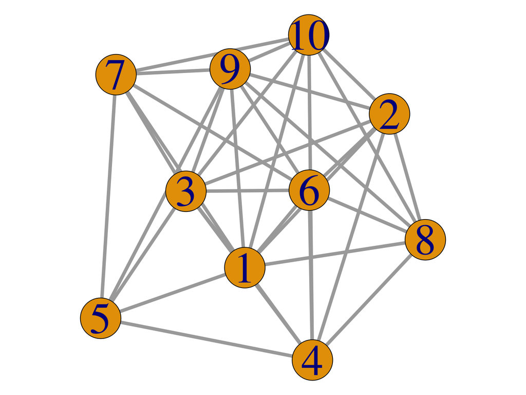

# List of types of unit-tests

Testing for **completeness**:

- #1: Checking that the function outputs something that is the correct type
- #2: Simple checks to make sure outputs are within the correct range
- #3: Making sure the function runs on many different inputs
  - I often randomly generate inputs for this
  - It’s useful to make sure your outputs **can** be different. If your function suspiciously always returns the same output regardless of what your input is, your function probably is’t correct
- #4: Testing to make sure it errors when expected
  - Usually, my tests for this are purposefully putting in “bad” inputs

Testing for **correctness**:

- #5: Making sure the function gets the correct answer for carefully crafted problem
  - Often, this becomes more than #6, since I do this for only simple settings
- #6: Testing to make sure the function handles corner cases gracefully
- #7: Testing the behavior when there is deliberately no unique answer
  - This is **very important** when it’s applicable.
  - It often requires you to know something mathematical about your function, where you carefully cook up a setting where there’s not a unique correct answer
- #8: Comparing against another known implementation
- #9: Comparing against another one of your implementations (possibly much more computationally intensive, but more transparent and definitely correct)
  - I use this **a lot**. Often, I have a “fast but very opaque” implementation of a function that I’m going to use at scale for my real project. My test would contain a “obviously correct when you read the code, but it’s very slow” implementation. Then, I just make sure both implementations yield the same input on a wide diversity of inputs.
  - This is very common for functions that do crazy matrix math – sometimes it’s easy to code the “wrong” matrix equation, but it’s also easy to code a cumbersome `for` loop that (mathematically) does the same thing but is very slow
- #10: (Math) Exploiting some mathematical property of your problem
  - This is as close as you can get to a **gold standard**, but it’s often not possible
  - This is usually: 1) exploiting some invariance in your function, or 2) checking the optimality conditions of an optimization problem
- #11: (Math) Comparing the relations between two different outputs of your function, given two different inputs
  - This is what most of my “more sophisicated” tests do

Elements #8 through #11 could all benefit from randomly generated inputs since you don’t really need to know what the exact output is to write a useful test!

- Remember, most sophisicated functions you will write will **not** actually have a “correct” answer that it’s easy to derive
  - Finding a maximal partial clique (Eeks! Your HW3)
  - Training a deep learning neural network
  - Hypothesis testing and confidence intervals
  - Methods that involve some type of randomness (typically as an initialization)
- However, you have to get creative on how to test that your implementation is **reasonable** (since it’s impossible to guarantee it’s “correct”)
  - **If you do not know how to test your code, then you don’t really understand your own code**

# Learn from other coders!

- I personally learn a **lot** reading how the authors themselves of R packages I use write their unit tests
  - `tiltedCCA` (Mine): https://github.com/linnykos/tiltedCCA/tree/master/tests/testthat
  - `radEmu` (by Amy): https://github.com/adw96/radEmu/tree/main/tests/testthat
  - `sensemakr` (by Carlos, in UW Stat) https://github.com/carloscinelli/sensemakr/tree/master/tests/testthat
  - `ggplot2`: https://github.com/tidyverse/ggplot2/tree/main/tests/testthat
  - Most R packages you use a lot are likely going to have tests

# Additional resources

- More on `testthat`: https://vita.had.co.nz/papers/testthat.pdf
- More on unit testing in R: https://r-pkgs.org/testing-basics.html

# With the remaining time…

- Go over the rest of HW3
  - I’m going to live-demo how to code with ChatGPT
  - The maximal partial clique is a bit of passion project of mine. It was the foundation of my first PhD paper and I haven’t had a great excuse to revisit this idea many years later
  - From “Lin, Kevin Z., Han Liu, and Kathryn Roeder.”Covariance-based sample selection for heterogeneous data: Applications to gene expression and autism risk gene detection.” Journal of the American Statistical Association 116.533 (2021): 54-67.”, https://github.com/linnykos/covarianceSelection
  - If you’re interested in chatting about the possible statistical uses of the maximal partial clique, come chat with me over the summer!

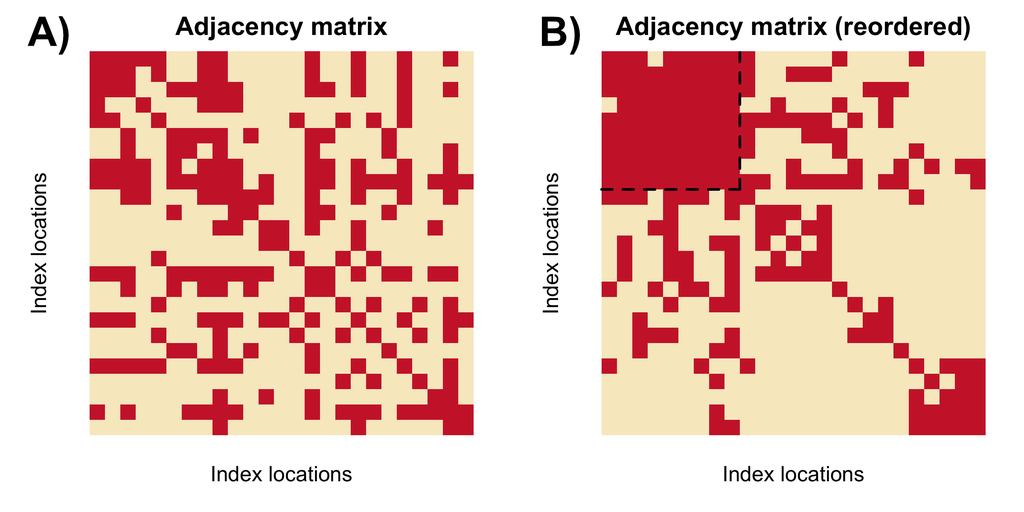